# 11_QC

Victor Yuan

April 28, 2019

QC week 24 chips, 192 samples

# 1.0 Libraries & data

```r
library(tidyr)
library(plyr)
library(minfi)
library(IlluminaHumanMethylationEPICanno.ilm10b4.hg19)
library(IlluminaHumanMethylationEPICmanifest)
library(ggplot2)
library(ggrepel)
library(irlba)
library(wateRmelon)
library(yahew) #install_github('wvictor14/yahew')
library(RColorBrewer)
library(dplyr)
library(kableExtra)
library(conumee)
library(doParallel)
library(ewastools)
library(stringr)
library(cowplot)
library(dendextend)
library(ggdendro)
library(pheatmap)
library(GGally)
library(grid)
library(yahew) # wvictor14/yahew github
library(umap)
```

```r
rgset <- readRDS('../../data/main/interim/01_rgset_raw.rds')
et_meth <- readRDS('../../data/main/interim/01_ewastools_loaded_idats.rds')
pDat <- pData(rgset) %>% as_tibble()
```

# 2.0 QC

We start with probe qc to remove any failed measurements before going into sample qc

## 2.1 Detection p-value

Here I test out EWAS tools. It estimates much more probes failing detection p.

In the end I use Minfi’s detection p the conventional way.

```r
#call detection p values using empirical negative control probes
et_meth <- ewastools::detectionP(et_meth)

# evaluate the effectiveness of this strategy
eval_detP_cutoffs(et_meth, males = which(pDat$Sex == 'M'), females = which(pDat$Sex == 'F'))

# set failed probes as NA
et_meth <- mask(et_meth, threshold = 0.5)

# get betas
et_beta <- dont_normalize(et_meth)
sum(is.na(et_beta))

pDat <- pDat %>%
  mutate(detP_01_ewastools = colSums(is.na(et_beta)))

ggplot(pDat, aes(x = Tissue, y = detP_01_ewastools)) +
  geom_boxplot() + geom_point() +coord_flip() + theme_bw() +
  labs(x = '', y = '# of probes with detection p > 0.01')  +
  geom_hline(yintercept = 0.05*nrow(et_beta), linetype ='dashed', color = 'blue') +
  geom_text(aes(x = 0, y = 0.05*nrow(et_beta), label = '5%', vjust = -0.5, hjust = -0.5),
            color = 'blue') +
  geom_hline(yintercept = 0.10*nrow(et_beta), linetype = 'dashed', color = 'red') +
  geom_text(aes(x = 0, y = 0.10*nrow(et_beta), label = '10%', vjust = -0.5, hjust = -0.5),
            color = 'red')  +
  geom_label_repel(data = pDat %>% filter(detP_01_ewastools > 6e+05),
                  aes(x = Tissue, y = detP_01_ewastools, label = Sample_Name))

ggplot(pDat %>% filter(detP_01_ewastools < 6e+05),
       aes(x = Tissue, y = detP_01_ewastools)) +
  geom_boxplot() + geom_point() +coord_flip() + theme_bw() +
  labs(x = '', y = 'Number of probes with detection p > 0.01') +
  geom_hline(yintercept = 0.05*nrow(et_beta), linetype ='dashed', color = 'blue') +
  geom_text(aes(x = 0, y = 0.05*nrow(et_beta), label = '5%', vjust = -0.5, hjust = -0.5),
            color = 'blue') +
  geom_hline(yintercept = 0.10*nrow(et_beta), linetype = 'dashed', color = 'red') +
  geom_text(aes(x = 0, y = 0.10*nrow(et_beta), label = '10%', vjust = -0.5, hjust = -0.5),
            color = 'red')  +
  geom_label_repel(data = pDat %>% filter(detP_01_ewastools > 0.05*nrow(et_beta) &
                                         detP_01_ewastools < 6e+05),
                   force = 150, size = 3.5,
                  aes(x = Tissue, y = detP_01_ewastools, label = Sample_Name))
```

```r
#get detp matrix
detp <- minfi::detectionP(rgset)

# detp p > 0.01
x <- colSums(detp > 0.01)
identical(names(x), pDat$Sentrix) #T
```

```
## [1] TRUE
```

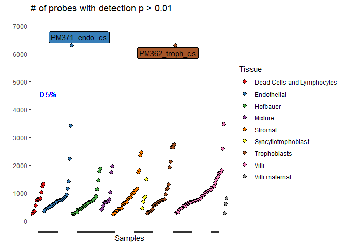

```r
pDat$detP_01_minfi <- x

# plot
pDat %>%
  arrange(Tissue, detP_01_minfi) %>%
  mutate(Sample_Name = factor(as.character(Sample_Name), levels = Sample_Name)) %>%
  ggplot(aes(x = Sample_Name, y = detP_01_minfi, fill = Tissue))+
  geom_point(shape = 21, col = 'black', size = 2.5) +
  labs(x = 'Samples', y ='',  title = '# of probes with detection p > 0.01')+
  geom_hline(yintercept = 0.005*nrow(detp), linetype ='dashed', color = 'blue') +
  geom_text(aes(x = 0, y = 0.005*nrow(detp)),
            label = '0.5%', vjust = -0.5, hjust = -0.5, color = 'blue') +
  geom_label_repel(data = pDat %>% filter(detP_01_minfi > 0.005*nrow(detp)),
                   aes(x = Sample_Name, y = detP_01_minfi, label = Sample_Name),
                   show.legend = F) +
  scale_y_continuous(limits = c(0, 7000), breaks = seq(0,7000, 1000)) +
  scale_fill_brewer(palette = 'Set1') +
  theme_classic()+
  theme(axis.text.x = element_blank())
```

No samples have > 8500 (1%) of their probes failing detection p

## 2.2 Beadcount

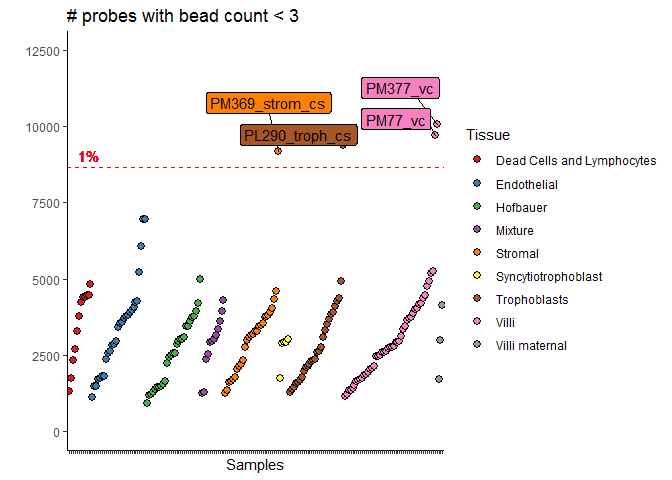

```r
# total bead count per sample
bc <- beadcount(rgset)
colnames(bc) <- gsub('X', '', colnames(bc))

pDat <- pDat %>% mutate(beadcount = colSums(is.na(bc)))

pDat %>%
  arrange(Tissue, beadcount) %>%
  mutate(Sample_Name = factor(as.character(Sample_Name), levels = Sample_Name)) %>%
  ggplot(aes(x = Sample_Name, y = beadcount, fill = Tissue)) +
  geom_point(shape = 21, col = 'black', size = 2.5) +
  geom_hline(yintercept = 0.01*nrow(bc), linetype = 'dashed', color = 'red') +
  geom_text(aes(x = 0, y = 0.01*nrow(bc)),
            label = '1%', vjust = -0.5, hjust = -0.5, color = 'red')+
  geom_label_repel(data = pDat %>% filter(beadcount > 0.01*nrow(detp)),
                   aes(x = Sample_Name, y = beadcount, label = Sample_Name),
                   nudge_y = 1000, force = 15, show.legend = F)+
  scale_fill_brewer(palette = 'Set1') +
  scale_y_continuous(limits = c(0, 12500), breaks = seq(0, 12500, 2500)) +
  labs(x = 'Samples', y = '', title = '# probes with bead count < 3') +
  theme_classic() +
  theme(axis.text.x = element_blank())
```

## 2.3 Detp and bead count

```r
# create a dummy matrix
failed_probes <- matrix(data = F, nrow = nrow(detp), ncol = ncol(detp),
                        dimnames = list(rownames(detp), colnames(detp))) %>% as.data.frame
failed_probes[1:6,1:6]
```

```
##            203067920143_R01C01 203067920143_R02C01 203067920143_R03C01
## cg18478105               FALSE               FALSE               FALSE
## cg09835024               FALSE               FALSE               FALSE
## cg14361672               FALSE               FALSE               FALSE
## cg01763666               FALSE               FALSE               FALSE
## cg12950382               FALSE               FALSE               FALSE
## cg02115394               FALSE               FALSE               FALSE
##            203067920143_R04C01 203067920143_R05C01 203067920143_R06C01
## cg18478105               FALSE               FALSE               FALSE
## cg09835024               FALSE               FALSE               FALSE
## cg14361672               FALSE               FALSE               FALSE
## cg01763666               FALSE               FALSE               FALSE
## cg12950382               FALSE               FALSE               FALSE
## cg02115394               FALSE               FALSE               FALSE
```

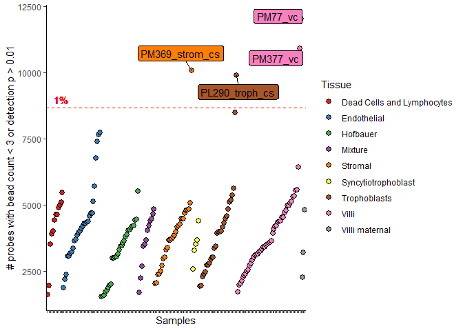

```r
# now put 'TRUE' where detp > 0.01, or beadcount is < 3
failed_probes[is.na(bc)] <- T
failed_probes[detp > 0.01] <- T

# now calculate the number of failed probes
pDat <- pDat %>% mutate(failed_probes = colSums(failed_probes))

pDat %>%
  arrange(Tissue, failed_probes) %>%
  mutate(Sample_Name = factor(as.character(Sample_Name), levels = Sample_Name)) %>%
  ggplot(aes(x = Sample_Name, y = failed_probes, fill = Tissue)) +
  geom_point(shape = 21, col = 'black', size = 2.5) +
  scale_fill_brewer(palette = 'Set1') +
  labs(x = 'Samples', y = '# probes with bead count < 3 or detection p > 0.01') +
  geom_hline(yintercept = 0.01*nrow(failed_probes), linetype = 'dashed', color = 'red') +
  geom_text(aes(x = 0, y = 0.01*nrow(bc)),
            label = '1%', vjust = -0.5, hjust = -0.5, color = 'red')+
  geom_label_repel(data = pDat %>% filter(failed_probes > 0.01*nrow(detp)),
                   aes(x = Sample_Name, y = failed_probes, label = Sample_Name),
                   force = 100, show.legend = F)+
  theme_classic()+
  theme(axis.text.x = element_blank())
```

Number of probes that had a significant amount of failures:

```r
n <- ncol(rgset)
failed_probes_count <- rowSums(failed_probes)
sum(failed_probes_count > 0.025*n) # > 2.5%, 40844
```

```
## [1] 40844
```

```r
sum(failed_probes_count > 0.05*n) # > 5%, 15249
```

```
## [1] 15249
```

```r
sum(failed_probes_count > 0.10*n) # > 10%, 3982
```

```
## [1] 3982
```

```r
sum(failed_probes_count > 0.15*n) # > 15%, 2095
```

```
## [1] 2095
```

```r
sum(failed_probes_count > 0.20*n) # > 20%, 1376
```

```
## [1] 1376
```

```r
sum(failed_probes_count > 0.25*n) # > 25%, 1022
```

```
## [1] 1022
```

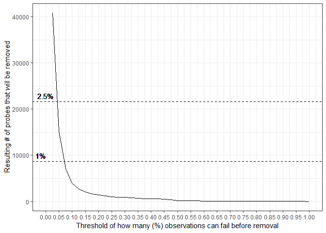

```r
fp_plot <- tibble(Percent_probes_failing = seq(0.025, 1, 0.025)) %>%
  mutate(Number_probes_remove =
           sapply(Percent_probes_failing*n, FUN = function(x) sum(failed_probes_count > x)))


ggplot(fp_plot, aes(x = Percent_probes_failing, y = Number_probes_remove)) +
  geom_line() + theme_bw() + scale_x_continuous(breaks = seq(0, 1, 0.05))+
  geom_hline(yintercept = 0.01*nrow(failed_probes), linetype = 'dashed') +
  geom_text(aes(x = 0, y = 0.01*nrow(bc)),
            label = '1%', vjust = -0.5, hjust = 1) +
  geom_hline(yintercept = 0.025*nrow(failed_probes), linetype = 'dashed') +
  geom_text(aes(x = 0, y = 0.025*nrow(bc)),
            label = '2.5%', vjust = -0.5, hjust = 0.5) +
  labs(x = 'Threshold of how many (%) observations can fail before removal',
       y = 'Resulting # of probes that will be removed')
```

```r
sum(failed_probes_count > 0.125*n) # > 12.5%, 2690
```

```
## [1] 2690
```

```r
# add this info to probe annotation
probe_anno <- tibble(probe_ID = rownames(detp)) %>%
  mutate(number_failed_probes = failed_probes_count)
```

## 2.4 Meth and unmeth

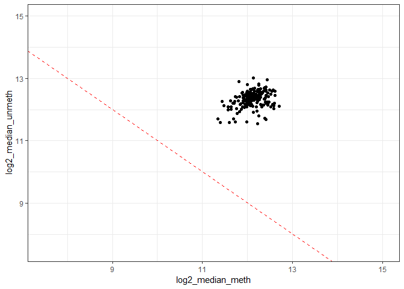

```r
mset_raw <- preprocessRaw(rgset)
meth <- getMeth(mset_raw)
unmeth <- getUnmeth(mset_raw)

pDat <- pDat %>% mutate(log2_median_meth = log2(colMedians(meth)),
                        log2_median_unmeth = log2(colMedians(unmeth)))

ggplot(pDat, aes(x = log2_median_meth, y = log2_median_unmeth)) +
  geom_point() +
  geom_abline(intercept = 10.5*2, slope = -1, col = 'red', linetype = 'dashed') +
  xlim(7.5, 15) + ylim(7.5, 15) + theme_bw()
```

## 2.5 Average intensity

Average intensity over green and red

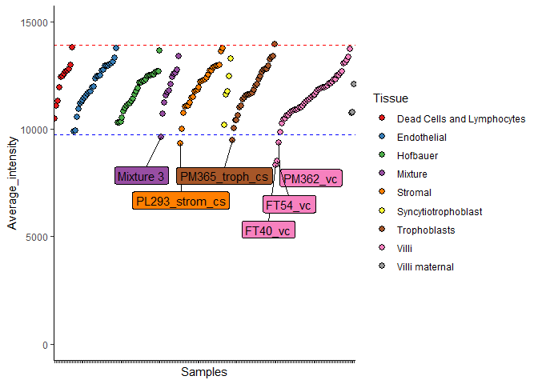

```r
green <- getGreen(rgset)
red <- getRed(rgset)
green_red <- green + red

# add to pDat and plot
pDat <- pDat %>% mutate(Average_intensity = colMeans(green_red))

pDat %>%
  arrange(Tissue, Average_intensity) %>%
  mutate(Sample_Name = factor(as.character(Sample_Name), levels = Sample_Name)) %>%
  ggplot(aes(x = Sample_Name, y = Average_intensity, fill = Tissue)) +
  geom_point(shape = 21, col = 'black', size = 2.5) + theme_classic() +
  theme(axis.text.x = element_blank()) +
  geom_hline(yintercept = mean(pDat$Average_intensity) - 2*sd(pDat$Average_intensity),
             linetype = 'dashed', col = 'blue')+
  geom_hline(yintercept = mean(pDat$Average_intensity) + 2*sd(pDat$Average_intensity),
             linetype = 'dashed', col = 'red') +
  geom_label_repel(data = pDat %>%
                    filter(Average_intensity < mean(pDat$Average_intensity) -
                             2*sd(pDat$Average_intensity)),
                  aes(label = Sample_Name), force = 10, nudge_y = -2500, show.legend = F) +
  scale_fill_brewer(palette ='Set1') +
  scale_y_continuous(limits = c(0, 15000)) +
  labs(x = 'Samples')
```

## 2.5 Control probes

ewastools

```r
#take out control matrix
ctrls <- control_metrics(et_meth)
sample_failure(ctrls) # no failures
```

```
##   [1] FALSE FALSE FALSE FALSE FALSE FALSE FALSE FALSE FALSE FALSE FALSE
##  [12] FALSE FALSE FALSE FALSE FALSE FALSE FALSE FALSE FALSE FALSE FALSE
##  [23] FALSE FALSE FALSE FALSE FALSE FALSE FALSE FALSE FALSE FALSE FALSE
##  [34] FALSE FALSE FALSE FALSE FALSE FALSE FALSE FALSE FALSE FALSE FALSE
##  [45] FALSE FALSE FALSE FALSE FALSE FALSE FALSE FALSE FALSE FALSE FALSE
##  [56] FALSE FALSE FALSE FALSE FALSE FALSE FALSE FALSE FALSE FALSE FALSE
##  [67] FALSE FALSE FALSE FALSE FALSE FALSE FALSE FALSE FALSE FALSE FALSE
##  [78] FALSE FALSE FALSE FALSE FALSE FALSE FALSE FALSE FALSE FALSE FALSE
##  [89] FALSE FALSE FALSE FALSE FALSE FALSE FALSE FALSE FALSE FALSE FALSE
## [100] FALSE FALSE FALSE FALSE FALSE FALSE FALSE FALSE FALSE FALSE FALSE
## [111] FALSE FALSE FALSE FALSE FALSE FALSE FALSE FALSE FALSE FALSE FALSE
## [122] FALSE FALSE FALSE FALSE FALSE FALSE FALSE FALSE FALSE FALSE FALSE
## [133] FALSE FALSE FALSE FALSE FALSE FALSE FALSE FALSE FALSE FALSE FALSE
## [144] FALSE FALSE FALSE FALSE FALSE FALSE FALSE FALSE FALSE FALSE FALSE
## [155] FALSE FALSE FALSE FALSE FALSE FALSE FALSE FALSE FALSE FALSE FALSE
## [166] FALSE FALSE FALSE FALSE FALSE FALSE FALSE FALSE FALSE FALSE FALSE
## [177] FALSE FALSE FALSE FALSE FALSE FALSE FALSE FALSE FALSE FALSE FALSE
## [188] FALSE FALSE FALSE FALSE FALSE
```

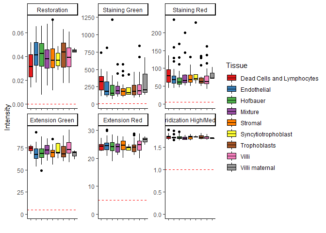

```r
# format as dat aframe
controls <- tibble(control = sapply(names(ctrls),
                                    function(x) paste0(x, '_', 1:192))  %>%
                     as.vector,
                   Intensity = unlist(ctrls)) %>%
  separate(control, into = c('Control', 'Sample'), sep = '_') %>%
  mutate(Sample = as.numeric(Sample)) %>%
  dplyr::select(Sample, Control, Intensity) %>%
  spread(key = Control, value = Intensity) %>%
  mutate(Sample_Name = pDat$Sample_Name,
         Tissue = pDat$Tissue) %>%
  dplyr::select(Sample_Name, Tissue, everything()) %>%
  dplyr::select(-Sample)

controls_melt <- controls %>%
  gather(key = Control, value = Intensity, -Sample_Name, -Tissue) %>%
  mutate(Control = factor(Control, levels = names(ctrls)))

# thresholds described per the beadchip manual
controls_thresholds <- tibble(
  Control = factor(levels(controls_melt$Control), levels = levels(controls_melt$Control)),
  Intensity = unlist(sapply(ctrls, attributes))
)

# plot
controls_melt %>%
  filter(Control %in% levels(Control)[1:6]) %>%
  ggplot(aes(x = Tissue, y = Intensity, fill = Tissue)) +
  geom_boxplot(col = 'black') +
  theme_classic() +
  theme(axis.text.x = element_blank()) +
  labs(x = '') +
  scale_fill_brewer(palette = 'Set1') +
  facet_wrap(~Control, scales = 'free') +
  scale_y_continuous(limits = c(0,NA)) +
  geom_hline(data = controls_thresholds %>% filter(Control %in% levels(Control)[1:6]),
             aes(yintercept = Intensity), col = 'red', linetype = 'dashed')
```

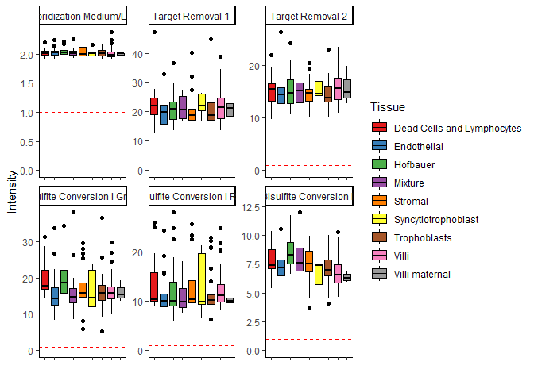

```r
controls_melt %>%
  filter(Control %in% levels(Control)[7:12]) %>%
  ggplot(aes(x = Tissue, y = Intensity, fill = Tissue)) +
  geom_boxplot(col = 'black') +
  theme_classic() +
  theme(axis.text.x = element_blank()) +
  labs(x = '') +
  scale_fill_brewer(palette = 'Set1') +
  facet_wrap(~Control, scales = 'free')+
  scale_y_continuous(limits = c(0,NA))+
  geom_hline(data = controls_thresholds %>% filter(Control %in% levels(Control)[7:12]),
             aes(yintercept = Intensity), col = 'red', linetype = 'dashed')
```

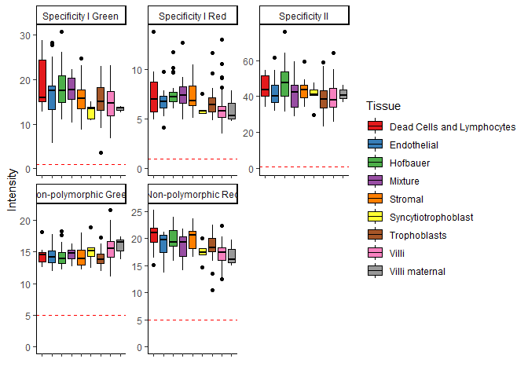

```r
controls_melt %>%
  filter(Control %in% levels(Control)[13:17]) %>%
  ggplot(aes(x = Tissue, y = Intensity, fill = Tissue)) +
  geom_boxplot(col = 'black') +
  theme_classic() +
  theme(axis.text.x = element_blank()) +
  labs(x = '') +
  scale_fill_brewer(palette = 'Set1') +
  facet_wrap(~Control, scales = 'free', nrow = 2)+
  scale_y_continuous(limits = c(0,NA)) +
  geom_hline(data = controls_thresholds %>% filter(Control %in% levels(Control)[13:17]),
             aes(yintercept = Intensity), col = 'red', linetype = 'dashed')
```

## 2.7 remove probes

Here I generate a list of probes to remove based on : - poor quality probes (high detp, low beadcount) - cross hybridizing probes (30bp non-unique, non-unique mapping) - probes with SNPs within 5bp of the CpG site, in probe direction, including CpG and SBE site

```r
# failed probes, remove if > 5% missing
probe_fail <- probe_anno %>% filter(number_failed_probes > 0.05*n)  %>% pull(probe_ID)
probe_fail %>% length # 15249
```

```
## [1] 15249
```

```r
probe_anno <- probe_anno %>% mutate(remove_failed = ifelse(probe_ID %in% probe_fail, T, F))
sum(probe_anno$remove_failed) # 15249
```

```
## [1] 15249
```

```r
# cross hybridizing AND snp in 5bp of target site, + SBE
# zhou's annotation
zhou_anno <- readRDS('Z:/Victor/Data/DNAm annotations/zhou2017_EPIC.hg19.manifest.rds')
zhou_anno <- zhou_anno %>% as_tibble() %>% mutate(probe_ID = names(zhou_anno))
glimpse(zhou_anno) # 865,918
```

```
## Observations: 865,918
## Variables: 58
## $ seqnames                 <fct> chr1, chr1, chr1, chr1, chr1, chr1, c...
## $ start                    <int> 10525, 10848, 10850, 15865, 18827, 29...
## $ end                      <int> 10526, 10849, 10851, 15866, 18828, 29...
## $ width                    <int> 2, 2, 2, 2, 2, 2, 2, 2, 2, 2, 2, 2, 2...
## $ strand                   <fct> -, +, +, -, -, -, -, -, -, +, +, +, -...
## $ address_A                <int> 21611527, 91693541, 82663207, 2665852...
## $ address_B                <int> NA, 47784201, 3701821, 39757192, NA, ...
## $ channel                  <chr> "Both", "Grn", "Grn", "Red", "Both", ...
## $ designType               <chr> "II", "I", "I", "I", "II", "I", "I", ...
## $ nextBase                 <chr> "G/A", "C", "C", "A", "G/A", "A", "T"...
## $ nextBaseRef              <chr> "C", "G", "G", "C", "C", "C", "A", "C...
## $ probeType                <chr> "cg", "cg", "cg", "cg", "cg", "cg", "...
## $ orientation              <chr> "down", "up", "up", "down", "down", "...
```

[output cut: 45 more lines]

```r
probe_CH_snp <- zhou_anno$probe_ID[zhou_anno$MASK_general == T]
length(probe_CH_snp) # 99360
```

```
## [1] 99360
```

```r
probe_anno <- probe_anno %>% mutate(remove_CH_SNP = ifelse(probe_ID %in% probe_CH_snp, T, F))
sum(probe_anno$remove_CH_SNP) # 99360
```

```
## [1] 99360
```

```r
# filter to sex probes
zhou_XY <- zhou_anno %>% filter(seqnames %in% c('chrX', 'chrY')) %>% pull(probe_ID)
zhou_X <- zhou_anno %>% filter(seqnames %in% c('chrX')) %>% pull(probe_ID)
zhou_Y <- zhou_anno %>% filter(seqnames %in% c('chrY')) %>% pull(probe_ID)
XY_probes <- intersect(zhou_XY, rownames(meth))
X_probes <- intersect(zhou_X, rownames(meth))
Y_probes <- intersect(zhou_Y, rownames(meth))

length(zhou_XY) # 19637
```

```
## [1] 19637
```

```r
length(XY_probes) # 19631, 6 xy probes in zhou's anno not in our data
```

```
## [1] 19631
```

```r
# indicate for sex probe
probe_anno <- probe_anno %>% mutate(remove_XY = ifelse(probe_ID %in% zhou_XY, T, F))
sum(probe_anno$remove_XY) # 19631
```

```
## [1] 19631
```

```r
# filter raw betas
remove <- probe_anno %>%
  filter(remove_failed == T | remove_CH_SNP == T | remove_XY == T) %>%
  pull(probe_ID)
length(remove) # 129041
```

```
## [1] 129041
```

```r
# how many probes removed based on CH and poor quality
probe_anno %>%
  filter(remove_failed == T | remove_CH_SNP == T) %>% nrow() # 112360
```

```
## [1] 112360
```

```r
betas_raw <- getBeta(rgset)
betas_raw_filt <- betas_raw[setdiff(rownames(betas_raw), remove),]
dim(betas_raw_filt) # 737050 probes
```

```
## [1] 737050    192
```

```r
# XY probes
XY_filt <- probe_anno %>%
  filter(remove_XY == T & remove_failed == F & remove_CH_SNP == F) %>%
  pull(probe_ID)
length(XY_filt) # 16681
```

```
## [1] 16681
```

```r
betas_raw_XY <- betas_raw[XY_filt,]
```

# 3.0 Sample QC

## 3.1 Sex Prediction

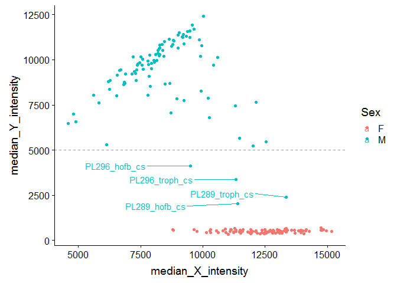

```r
# calculat total intensities for each probe
MU_total <- meth + unmeth

# calculate median intensity across X and Y probes
pDat <- pDat %>%
  mutate(median_X_intensity = colMedians(MU_total[X_probes,]),
         median_Y_intensity = colMedians(MU_total[Y_probes,]))
ggplot(pDat, aes(x = median_X_intensity, y = median_Y_intensity, col = Sex)) +
  geom_point() +
  geom_text_repel(data = pDat %>% filter(Sex == 'M', median_Y_intensity < 5000),
                  aes(label = Sample_Name), nudge_x = -3000, force = 15) +
  geom_hline(yintercept = 5000, linetype = 'dashed', col = '#9B9B9B')
```

3. ewastools check sex

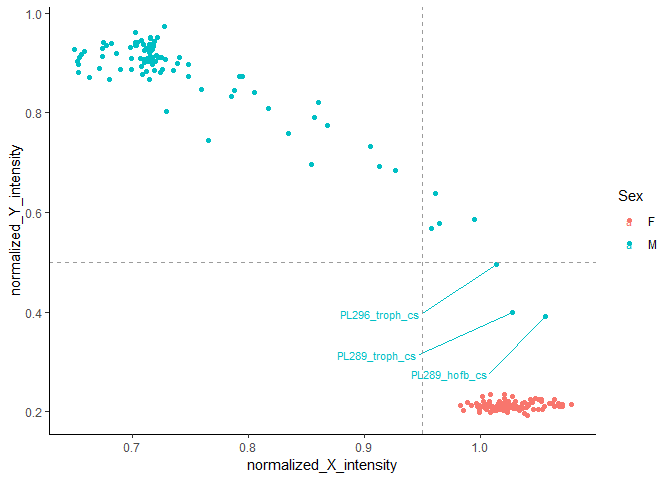

```r
predicted_sex <- check_sex(et_meth)
pDat <- pDat %>% mutate(normalized_X_intensity = predicted_sex$X,
                        normalized_Y_intensity = predicted_sex$Y)
ggplot(pDat, aes(x = normalized_X_intensity, y = normalized_Y_intensity, col = Sex)) +
  geom_point() +theme_classic() +
  geom_text_repel(data = pDat %>% filter(Sex == 'M', normalized_X_intensity > 0.95,
                                         normalized_Y_intensity < 0.5),
            aes(label = Sample_Name), size = 3, force = 15, nudge_x = -0.1, nudge_y = -0.1) +
  geom_hline(yintercept = 0.5, linetype = 'dashed', col = '#9B9B9B') +
  geom_vline(xintercept = 0.95, linetype = 'dashed', col = '#9B9B9B')
```

Flag samples that appear as outliers

```r
pDat <- pDat %>%
  mutate(Flag_Sex = case_when(
    Sex == 'M' & (normalized_X_intensity > 0.95 & normalized_Y_intensity <0.5) ~ T,
    Sex == 'M' & median_Y_intensity < 5000 ~ T,
    TRUE ~ F))# if not matched then return
```

## 3.2 Genotype checking

### ewastools

infers genotypes using 3 component mixture models on snp betas, and another 4th component uniform distribution to catch outliers.

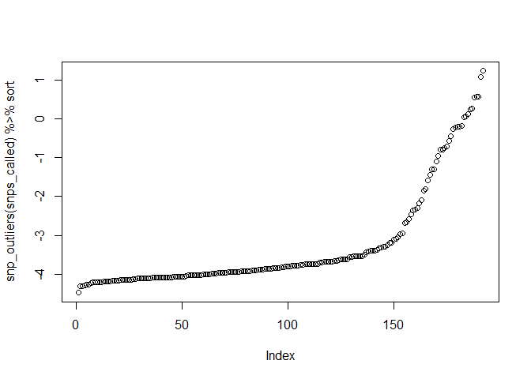

```r
#snps <- getSnpBeta(rgset)

#ewastools pipeline
snps <- et_meth$manifest[probe_type=="rs",index]
et_betas <- dont_normalize(et_meth)
snps <- et_betas[snps,]

# fit mixture model to call genotypes
snps_called <- call_genotypes(snps, learn = T)

# call genotype clusters
pDat <- pDat %>% mutate(genotype_cluster = as.factor(enumerate_sample_donors(snps_called)))

# examine probability outlier
plot(snp_outliers(snps_called) %>% sort)
```

```r
# find any discrepancies
genotype_issues <- check_snp_agreement(snps_called, donor_ids = pDat$Case_ID,
                                       sample_ids = pDat$Sample_Name)
genotype_issues_df <- do.call("rbind", genotype_issues) %>% as_tibble

# add sex results
genotype_issues_df <- genotype_issues_df %>%
  left_join(pDat %>% dplyr::select(Sample_Name, Flag_Sex),
            by = c('sample1' = 'Sample_Name')) %>% rename(Flag_Sex_sample1 = Flag_Sex) %>%
  left_join(pDat %>% dplyr::select(Sample_Name, Flag_Sex),
            by = c('sample2' = 'Sample_Name'))  %>% rename(Flag_Sex_sample2 = Flag_Sex) %>%
  select(contains('1'), contains('2'), agreement)


# GROUP ROWS
kable(genotype_issues_df %>% select(-contains('donor'))) %>%
   kable_styling(bootstrap_options = c("striped", "hover", "condensed"), full_width = F) %>%
  pack_rows(index = sapply(genotype_issues, nrow),
            label_row_css = "background-color: #C0C0C0; color: #fff;")
```

| sample1 | Flag_Sex_sample1 | sample2 | Flag_Sex_sample2 | agreement |
| --- | --- | --- | --- | --- |
| **1** |  |  |  |  |
| PL290_v | FALSE | PL290_hofb_cs | FALSE | 0.8093798 |
| **2** |  |  |  |  |
| PL296_v | FALSE | PL296_hofb_cs | TRUE | 0.7767398 |
| PL296_v | FALSE | PL296_troph_cs | TRUE | 0.6671205 |
| **3** |  |  |  |  |
| PL289_hofb_cs | TRUE | PL289_v | FALSE | 0.5728336 |
| PL289_hofb_cs | TRUE | PL289_strom_cs | FALSE | 0.8074485 |
| PL289_v | FALSE | PL289_troph_cs | TRUE | 0.5854478 |
| PL289_strom_cs | FALSE | PL289_troph_cs | TRUE | 0.8279103 |
| **4** |  |  |  |  |
| PL292_troph_cs | FALSE | PL292_v | FALSE | 0.8221942 |
| PL292_v | FALSE | PL292_hofb_cs | FALSE | 0.8394129 |
| **5** |  |  |  |  |
| PL293_discard_cs | FALSE | PL293_endo_cs | FALSE | 0.8831524 |
| **6** |  |  |  |  |
| PL294_v | FALSE | PL294_hofb_cs | FALSE | 0.8358081 |
| PL294_v | FALSE | PL294_troph_cs | FALSE | 0.6434783 |
| **7** |  |  |  |  |
| P128_endo_cs | FALSE | P128_hofb_cs | FALSE | 0.7945382 |
| P128_troph_cs | FALSE | P128_hofb_cs | FALSE | 0.8385738 |
| P128_strom_cs | FALSE | P128_hofb_cs | FALSE | 0.7808438 |

```r
# flag samples
pDat <- pDat %>%
  mutate(Flag_genotype = ifelse(Sample_Name %in% c(genotype_issues_df$sample1,
                                                   genotype_issues_df$sample2),
                                T, F))
```

Looks like there are some low confidence assignments, but these are still the correct Case_IDs for these samples. So it might be a sample quality issue

### clustering on snps

Here I cluster on snp betas

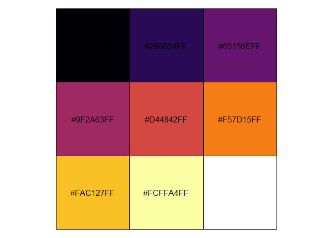

```r
# extract snp matrix
snp_betas <- getSnpBeta(rgset)
colnames(snp_betas) <- pDat$Sample_Name

#distance
D <- dist(t(snp_betas)) #snp probes

# clustering
clust <- hclust(D)
dendo <- as.dendrogram(clust)

# get number of tissues and assign a color
#n_class<- length(unique(pDat$Case_ID))
#col_pal <- viridis_pal()(n_class)

# map it to Tissue
#colors_to_use <- col_pal[as.numeric(as.factor(pDat$Case_ID))]

# sort them based on their order in dend:
#colors_to_use <- colors_to_use[order.dendrogram(dendo)]
#colors_to_use

show_col(viridis_pal(option = 'inferno')(8))
```

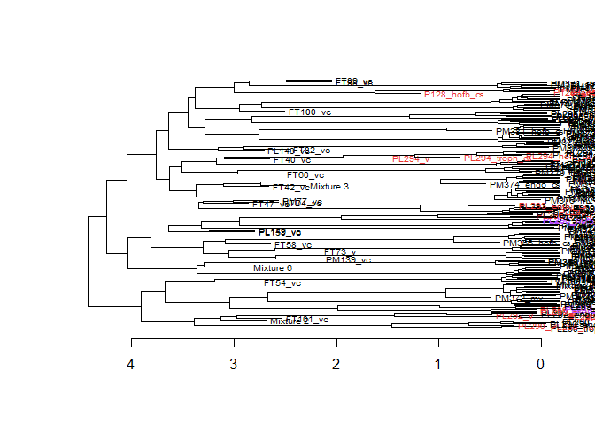

```r
#samples to highlight:
Flagged_genotype <- pDat %>% filter(Flag_genotype == T) %>% pull(Sample_Name)
Flagged_sex <- pDat %>% filter(Flag_Sex == T) %>% pull(Sample_Name)

dendo %>% set("labels_cex", 0.6) %>%
 #set("branches_col", colors_to_use) %>%
  color_labels(labels = Flagged_genotype, col = "#E93535") %>% # red = genotype flagged
  color_labels(labels = Flagged_sex, col = "#B84EFF") %>% # purple = sex flagged
  hang.dendrogram %>%
  plot(horiz = T)
```

Hard to see with so many samples. Saving this to as a vector graphic (e.g. pdf) will allow for an easier view (can zoom in with no loss of resolution).

```r
#save to pdf
pdf('../../outs/11_snp_clustering.pdf')
par(mar=c(2,1,1.5,6))
dendo %>% set("labels_cex", 0.25) %>%

  # highlight flagged samples
  color_labels(labels = Flagged_genotype, col = "#E93535") %>% # red = genotype flagged
  color_labels(labels = Flagged_sex, col = "#B84EFF") %>% # purple = sex flagged
  hang.dendrogram %>%
  plot(horiz = T, cex.main = 0.6,
       main = 'Red: flagged for low genotype agreement\nBlue: flagged for unusual sex methylation')
dev.off()
```

### correlation on snps

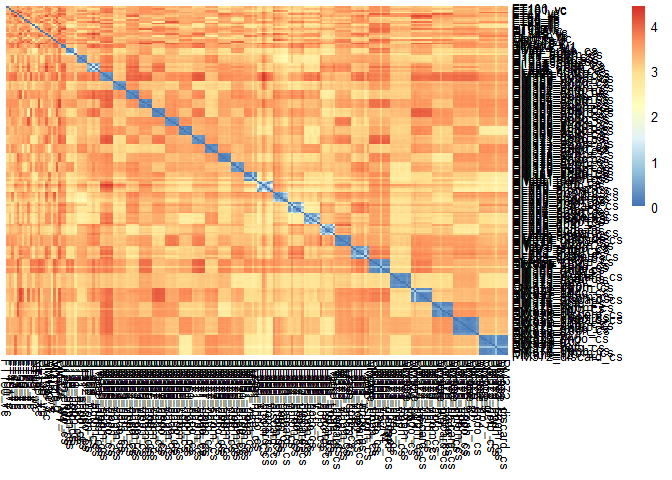

```r
ind <- pDat %>%
  add_count(Case_ID) %>%
  arrange(n, Case_ID) %>%
  pull(Sample_Name)

# distance
pheatmap(as.matrix(D)[ind,ind], cluster_cols = F, cluster_rows = F)
```

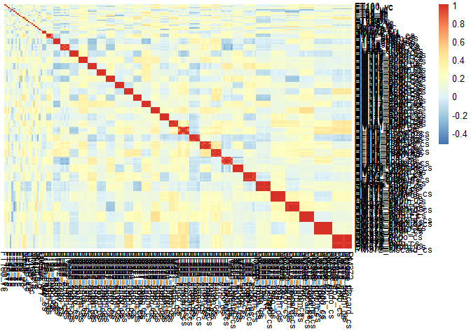

```r
# correlation
C <- cor(snp_betas[,ind])
pheatmap(as.matrix(C), cluster_cols = F, cluster_rows = F)
```

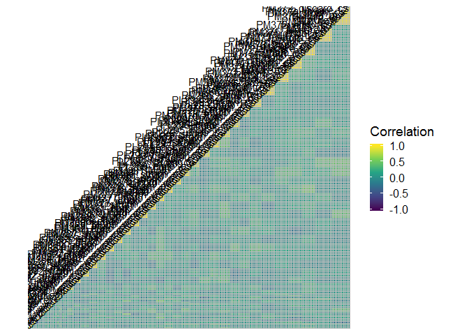

```r
# Save correlation matrix
C_save <- C

# replace upper triangle with NAs
C[upper.tri(C)] <- NA


# reshape
C_melt <- C %>%
  as_tibble() %>%
  mutate(Sample1 = factor(ind, levels = ind)) %>%
  gather(key = Sample2, value = Correlation, -Sample1) %>%
  mutate(Sample2 = factor(Sample2, levels = levels(Sample1)))

g1 <- ggplot(na.omit(C_melt), aes(x = Sample1, y = Sample2, fill = Correlation)) +
  geom_tile(col = 'grey') +
  geom_text(data = C_melt %>% filter(Sample1 == Sample2),
              aes(x = Sample1, y = Sample2, label = Sample1, hjust = 1)) +
  scale_fill_viridis_c(limits = c(-1, 1))  +
  scale_x_discrete(breaks = NULL, limits = ind) +
  scale_y_discrete(breaks = NULL, limits = ind) +
  labs(x = NULL, y = NULL) +
  coord_equal() +
  theme(panel.background = element_blank(),
        legend.key = element_blank());g1
```

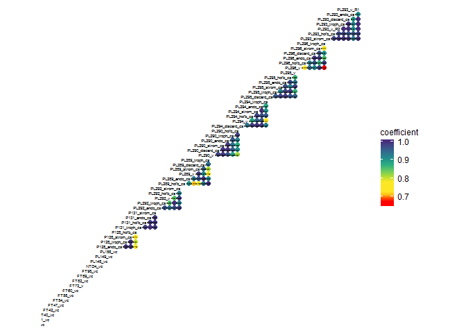

```r
# divide into 3 plots

# organize by and trimester
indx <- pDat %>%
  add_count(Case_ID) %>%
  mutate(Trimester = factor(as.character(Trimester), levels = c('Second', 'First', 'Third'))) %>%
  arrange(Trimester, n, Case_ID) %>%
  pull(Sample_Name)


ind1 <- indx[1:66]
ind2 <- indx[67:123]
ind3 <- indx[124:192]

label_size <- 1.5
point_size <- 2.2
r_size <- 0.85
colors <- c('red', 'red', rev(viridis_pal(option = 'D')(9))[c(1,1,1:8)])
r_limit <- c(0.65,1)

g2 <- ggcorr(data = NULL, cor_matrix = C[ind1,ind1],
             geom = 'blank', name = expression(rho), size = label_size, hjust = 0.95) +
  geom_point(aes(col = coefficient), size = point_size) +
  geom_text(data = function(x) dplyr::filter(x, coefficient > r_limit[1]),
            aes(label = prettyNum(coefficient, digits = 2)),
            size = r_size) +
  scale_color_gradientn(colours = colors,
                        limits = r_limit, na.value = 'white');g2
```

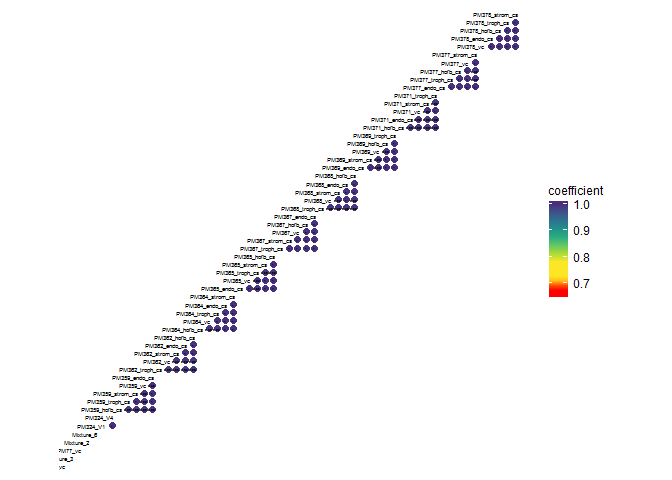

```r
g3 <- ggcorr(data = NULL, cor_matrix = C[ind2,ind2],
             geom = 'blank', name = expression(rho), size = label_size, hjust = 0.95) +
  geom_point(aes(col = coefficient), size = point_size) +
  geom_text(data = function(x) dplyr::filter(x, coefficient > r_limit[1]),
            aes(label = prettyNum(coefficient, digits = 2)),
            size = r_size) +
  scale_color_gradientn(colours = colors,
                        limits = r_limit, na.value = 'white');g3
```

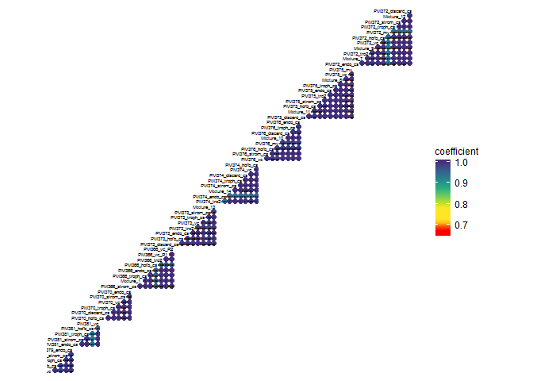

```r
g4 <- ggcorr(data = NULL, cor_matrix = C[ind3,ind3],
             geom = 'blank', name = expression(rho), size = label_size, hjust = 0.95) +
  geom_point(aes(col = coefficient), size = point_size) +
  geom_text(data = function(x) dplyr::filter(x, coefficient > r_limit[1]),
            aes(label = prettyNum(coefficient, digits = 2)),
            size = r_size) +
  scale_color_gradientn(colours = colors,
                        limits = r_limit, na.value = 'white');g4
```

pdf(‘../../outs/11_snp_cor_set1.pdf’) g2 dev.off() pdf(‘../../outs/11_snp_cor_set2.pdf’) g3 dev.off() pdf(‘../../outs/11_snp_cor_set3.pdf’) g4 dev.off()

### Within case correlations

To calculate average correlation within group, we need to ensure that we have all comparisons in a single column.

So

P1_troph - P1_endo P1_troph - P1_hofb p1_troph - P1_strom

Needs to be represented as two columns where

P1_troph P1_troph p1_troph

is in columns one, and

P1_endo P1_hofb P1_strom

is in column two

Right now, the data is arranged as:

P1_troph - P1_endo P1_troph - P1_hofb P1_strom - p1_troph

So to fix this, we have to bind these two columns rowwise twice, flipping the columns of one these sets:

Original matrix: P1_troph - P1_endo **P1_troph - P1_hofb** P1_strom - p1_troph

```r
# pull out those cases with some samples low correlation
# add in case ID for sample 1 and sample 2
C_melt2 <- C_melt %>%
  left_join(pDat %>% select(Sample_Name, Case_ID), by = c('Sample1' = 'Sample_Name')) %>%
  rename(Case_ID1 = Case_ID) %>%
  left_join(pDat %>% select(Sample_Name, Case_ID), by = c('Sample2' = 'Sample_Name')) %>%
  rename(Case_ID2 = Case_ID)
```

```r
# filter such that we have only within case comparisons,
# excluding the same sample comparison (when correlation = 1)
# note that this removes cases with only a single sample (e.g. 2nd trimester villi)
Ca <- C_melt2 %>%
  filter(Case_ID1 == Case_ID2, Correlation != 1)

# flip the matrix
Cb <- C_melt2 %>%
  filter(Case_ID1 == Case_ID2, Correlation != 1) %>%
  rename(Sample2 = Sample1, Case_ID2 = Case_ID1,
         Sample1 = Sample2, Case_ID1 = Case_ID2)

C_melt3 <- rbind(Ca, Cb) %>%

  # average correlation to all other members of case
  group_by(Sample1) %>%
  summarize(Average_cor = mean(Correlation, na.rm = T)) %>%

  # add Tissue and CasE_ID
  left_join(pDat %>% select(Sample_Name, Tissue, Case_ID, contains('Flag')),
            by = c('Sample1' = 'Sample_Name')) %>%

  #Prepare for plotting
  arrange(desc(Average_cor)) %>%
  mutate(Sample1 = factor(as.character(Sample1), levels = Sample1))
C_melt3
```

```
## # A tibble: 171 x 6
##    Sample1      Average_cor Tissue           Case_ID Flag_Sex Flag_genotype
##    <fct>              <dbl> <chr>            <chr>   <lgl>    <lgl>
##  1 PM378_endo_~       0.998 Endothelial      PM378   FALSE    FALSE
##  2 PM378_hofb_~       0.997 Hofbauer         PM378   FALSE    FALSE
##  3 PM370_disca~       0.997 Dead Cells and ~ PM370   FALSE    FALSE
##  4 PM367_strom~       0.997 Stromal          PM367   FALSE    FALSE
##  5 PM364_strom~       0.997 Stromal          PM364   FALSE    FALSE
##  6 PM370_endo_~       0.997 Endothelial      PM370   FALSE    FALSE
##  7 PM367_vc           0.997 Villi            PM367   FALSE    FALSE
##  8 PM377_endo_~       0.997 Endothelial      PM377   FALSE    FALSE
##  9 PM367_endo_~       0.997 Endothelial      PM367   FALSE    FALSE
## 10 PM378_troph~       0.997 Trophoblasts     PM378   FALSE    FALSE
## # ... with 161 more rows
```

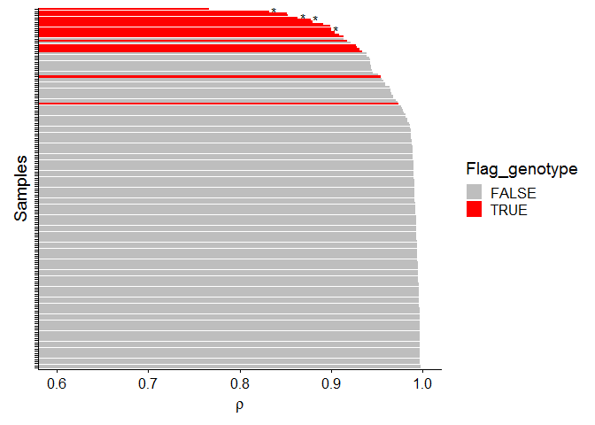

```r
# all samples
#stars indicate flagged for sex
ggplot(C_melt3, aes(x = Sample1, y = Average_cor)) +
  geom_bar(stat = 'identity', aes(fill = Flag_genotype)) +
  geom_text(data = C_melt3 %>% filter(Flag_Sex == T),
            aes(x = Sample1, y = Average_cor, label = '*'), nudge_y = 0.005) +
  scale_fill_manual(values = c('TRUE' = 'Red', 'FALSE' = 'Grey'))+
  labs(x = 'Samples', y = expression(rho)) +
  coord_flip(ylim = c(0.6, 1))+
  theme(axis.text.y = element_blank())
```

```r
# What are these flagged samples with high snp correlation?
C_melt3 %>% filter(Average_cor > 0.93, Flag_genotype == T) %>% kable %>% kable_styling()
```

| Sample1 | Average_cor | Tissue | Case_ID | Flag_Sex | Flag_genotype |
| --- | --- | --- | --- | --- | --- |
| PL293_discard_cs | 0.9730637 | Dead Cells and Lymphocytes | PL293 | FALSE | TRUE |
| PL294_hofb_cs | 0.9539664 | Hofbauer | PL294 | FALSE | TRUE |
| PL292_troph_cs | 0.9340620 | Trophoblasts | PL292 | FALSE | TRUE |
| PL292_hofb_cs | 0.9305104 | Hofbauer | PL292 | FALSE | TRUE |

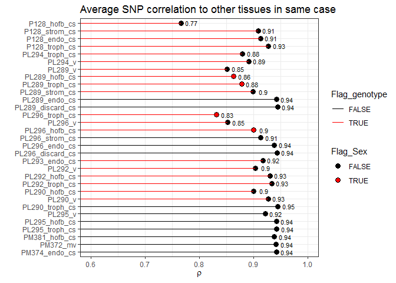

```r
## plot just those with low correlation
# first arrange samples by their groups average correlation:
C_melt3 %>% filter(Average_cor < 0.95) %>%
  group_by(Case_ID) %>% mutate(case_cor = mean(Average_cor)) %>% ungroup() %>%
  arrange(desc(case_cor), Case_ID, desc(Average_cor)) %>%
  mutate(Sample1 = factor(as.character(Sample1), levels = Sample1)) %>%
  ggplot(aes(x = Sample1, y = Average_cor)) +
  geom_point(aes(fill = Flag_Sex), shape = 21, size = 3) +
  scale_fill_manual(values = c('TRUE' = 'Red', 'FALSE' = 'Black'))+
  geom_segment(aes(col = Flag_genotype, xend = Sample1, yend = Average_cor, y = 0))+
  scale_color_manual(values = c('TRUE' = 'Red', 'FALSE' = 'Black'))+
  geom_text(aes(label = prettyNum(Average_cor, digits = 2)), nudge_y = 0.02, size = 3) +
  labs(x = '', y = expression(rho), title = 'Average SNP correlation to other tissues in same case') +
  coord_flip(ylim = c(0.6, 1))+
  theme_bw()
```

These samples with low correlations / agreement on SNP data are a concern because their methylation data may be equally messed up.

It seems apparent that these samples are mostly cell sorted samples from first trimester. Let’s add their average within-case snp correlation to pData and see if we can detect any associations.

```r
pDat <- pDat %>%
  left_join(C_melt3 %>% select(Sample1, Average_cor), by = c('Sample_Name' = 'Sample1'))
```

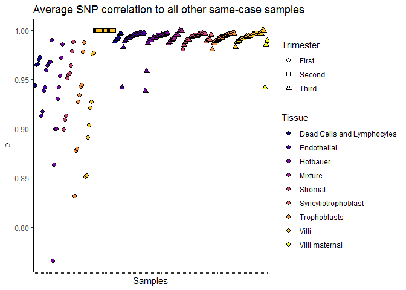

```r
# NA is where the case_ID group contains only 1 sample, so here I replace those NAs with 1
pDat <- pDat %>%
  mutate(Average_cor = ifelse(is.na(Average_cor), 1, Average_cor))  %>%
  rename(Average_SNP_cor_within_donor = Average_cor)

pDat %>% arrange(Trimester, Tissue, Average_SNP_cor_within_donor) %>%
  mutate(Sample_Name = factor(as.character(Sample_Name), levels = Sample_Name)) %>%
  ggplot(aes(x = Sample_Name, y = Average_SNP_cor_within_donor, fill = Tissue, Shape = Trimester)) +
  geom_point(aes(shape = Trimester), col = 'black', size = 2)  +
  labs(x = 'Samples', y = expression(rho),
       title = 'Average SNP correlation to all other same-case samples') +
  theme_classic() +
  theme(axis.text.x = element_blank()) +
  scale_shape_manual(values = c('First' = 21, 'Second' = 22, 'Third' = 24)) +
  scale_fill_viridis_d(option = "C") +
  guides(fill=guide_legend(override.aes=list(shape=21)))
```

```r
# flag samples below a certain correlation
pDat <- pDat %>% mutate(Flag_genotype = ifelse(Average_SNP_cor_within_donor < 0.9, T, F))

table(pDat$Flag_genotype, pDat$Chip_number)
```

```
##
##         25 26 27 28 29 30 31 32 33 34 35 36 37 38 39 40 41 42 43 44 45 46
##   FALSE  8  8  8  6  8  8  8  7  8  7  8  8  7  8  8  8  7  8  8  7  8  8
##   TRUE   0  0  0  2  0  0  0  1  0  1  0  0  1  0  0  0  1  0  0  1  0  0
##
##         47 48
##   FALSE  7  7
##   TRUE   1  1
```

```r
table(pDat$Flag_genotype, pDat$Row)
```

```
##
##          1  2  3  4  5  6  7  8
##   FALSE 22 23 23 22 24 23 22 24
##   TRUE   2  1  1  2  0  1  2  0
```

```r
table(pDat$Flag_genotype, pDat$Sex)
```

```
##
##          F  M
##   FALSE 94 89
##   TRUE   3  6
```

```r
table(pDat$Flag_genotype, pDat$Week)
```

```
##
##          1  2
##   FALSE 92 91
##   TRUE   4  5
```

```r
table(pDat$Flag_genotype, pDat$Batch_BSC)
```

```
##
##         BSC_TEST BSC0 BSC1 BSC2 BSC3
##   FALSE        5    8   57   62   51
##   TRUE         3    0    1    2    3
```

Not really strongly associated with anything

Let’s see if first trimester samples have variable intensities. Here we use the average intensity across red and green that we calculated previously:

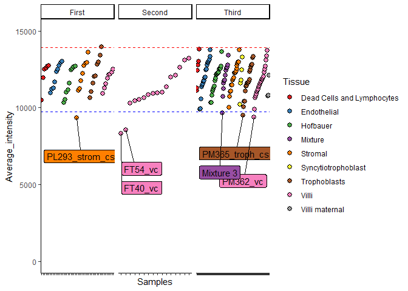

```r
pDat %>%
  arrange(Trimester, Tissue, Average_intensity) %>%
  mutate(Sample_Name = factor(as.character(Sample_Name), levels = Sample_Name)) %>%
  ggplot(aes(x = Sample_Name, y = Average_intensity, fill = Tissue)) +
  geom_point(shape = 21, col = 'black', size = 2.5) + theme_classic() +
  theme(axis.text.x = element_blank()) +
  geom_hline(yintercept = mean(pDat$Average_intensity) - 2*sd(pDat$Average_intensity),
             linetype = 'dashed', col = 'blue')+
  geom_hline(yintercept = mean(pDat$Average_intensity) + 2*sd(pDat$Average_intensity),
             linetype = 'dashed', col = 'red') +
  geom_label_repel(data = pDat %>%
                    filter(Average_intensity < mean(pDat$Average_intensity) -
                             2*sd(pDat$Average_intensity)),
                  aes(label = Sample_Name), force = 10, nudge_y = -2500, show.legend = F) +
  scale_fill_brewer(palette ='Set1') +
  scale_y_continuous(limits = c(0, 15000)) +
  labs(x = 'Samples') +
  facet_wrap(~Trimester, ncol = 3, scales = 'free_x')
```

Doesn’t appear to explain these

### Contamination

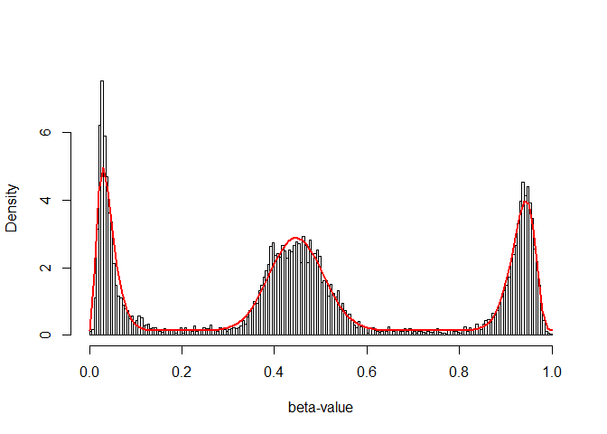

```r
# ewastools probability belong to the uniform distribution over normals
mxm_(snps_called)
```

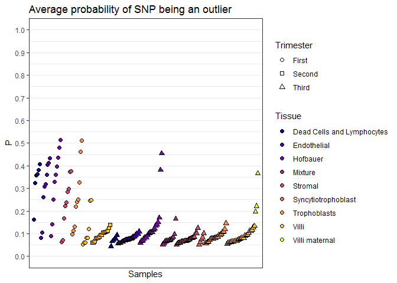

```r
# average probability over all snps being classified to the uniform, for each sample
pDat <- pDat %>%
  mutate(Prob_SNP_outlier = colMeans(snps_called$outliers, na.rm = T),
         Prob_SNP_outlier_Logodds = snp_outliers(snps_called))

pDat %>% arrange(Trimester, Tissue, Prob_SNP_outlier) %>%
  mutate(Sample_Name = factor(as.character(Sample_Name), levels = Sample_Name)) %>%
  ggplot(aes(x = Sample_Name, y = Prob_SNP_outlier, fill = Tissue, Shape = Trimester)) +
  geom_point(aes(shape = Trimester), col = 'black', size = 2)  +
  labs(x = 'Samples', y = "P",
       title = 'Average probability of SNP being an outlier') +
  theme_bw() +
  theme(axis.text.x = element_blank()) +
  scale_shape_manual(values = c('First' = 21, 'Second' = 22, 'Third' = 24)) +
  scale_fill_viridis_d(option = "C") +
  guides(fill=guide_legend(override.aes=list(shape=21))) +
  scale_y_continuous(limits = c(0,1), breaks = seq(0,1,0.1)) +
  scale_x_discrete(breaks = NULL, expand = c(0.02, 0.02))
```

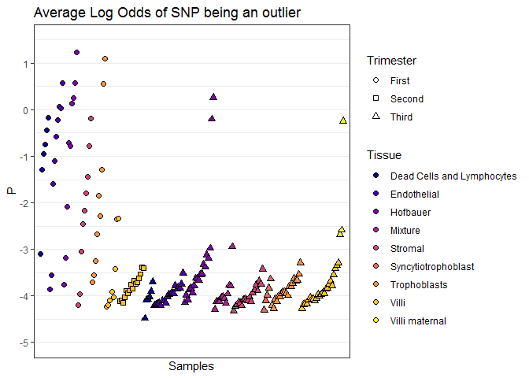

```r
pDat %>% arrange(Trimester, Tissue, Prob_SNP_outlier) %>%
  mutate(Sample_Name = factor(as.character(Sample_Name), levels = Sample_Name)) %>%
  ggplot(aes(x = Sample_Name, y = Prob_SNP_outlier_Logodds, fill = Tissue, Shape = Trimester)) +
  geom_point(aes(shape = Trimester), col = 'black', size = 2)  +
  labs(x = 'Samples', y = "P",
       title = 'Average Log Odds of SNP being an outlier') +
  theme_bw() +
  theme(axis.text.x = element_blank()) +
  scale_shape_manual(values = c('First' = 21, 'Second' = 22, 'Third' = 24)) +
  scale_fill_viridis_d(option = "C") +
  guides(fill=guide_legend(override.aes=list(shape=21))) +
  scale_y_continuous(limits = c(-5,1.5), breaks = -5:1) +
  scale_x_discrete(breaks = NULL, expand = c(0.02, 0.02))
```

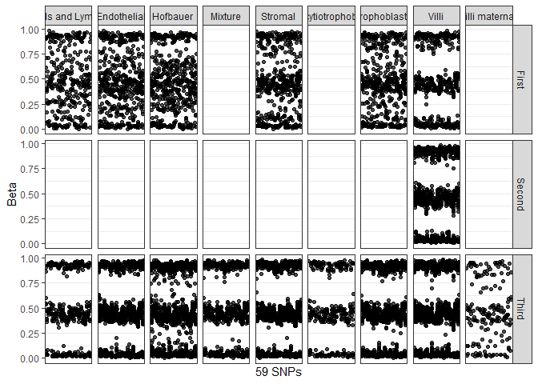

```r
# look at the raw distribution
snp_betas_melt <- t(snp_betas) %>% as_tibble %>% mutate(Sample_Name = colnames(snp_betas)) %>%
  left_join(pDat %>% select(Sample_Name, Tissue, Trimester), by = 'Sample_Name') %>%
  gather(key = 'SNP', value = 'Beta', -Sample_Name, -Tissue, -Trimester)

ggplot(snp_betas_melt, aes(x = SNP, y = Beta)) +
  geom_point(alpha = 0.7, color = 'black') +
  labs(x = '59 SNPs') + theme_bw() + theme(axis.text.x =element_blank()) +
  facet_grid(Trimester ~ Tissue) +
  theme_bw() +
  theme(axis.text.x = element_blank()) +
  scale_x_discrete(breaks = NULL, expand = c(0.02, 0.02))
```

## 3.3 PCA

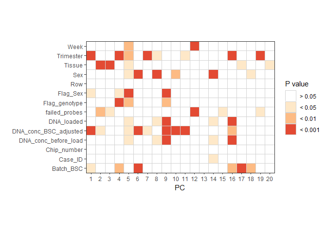

```r
# calculate pca
set.seed(2019)
pca_raw <- prcomp_irlba(t(na.omit(betas_raw)), n = 20)

# rename columns
pca_raw_scores <-pca_raw$x %>% as_tibble() %>% mutate(Sample_Name = pDat$Sample_Name)
colnames(pca_raw_scores)[1:20] <- paste0(colnames(pca_raw_scores)[1:20], '_raw')

# factorize some variables encoded as numeric
pDat <- pDat %>%
  mutate(Week = as.factor(as.character(Week)),
         Chip_number = as.factor(as.character(Chip_number)),
         Row = as.factor(as.character(Row)))

# correlate with phenodata
pca_raw_cor <- lmmatrix(dep = pca_raw_scores[,1:20],
                        ind = pDat %>%
                          dplyr::select(Case_ID, Tissue, Sex, Trimester, #bio
                                        Week, Chip_number, Row, Batch_BSC, # batch
                                        DNA_conc_BSC_adjusted, DNA_conc_before_load, DNA_loaded,
                                        failed_probes, Flag_Sex, Flag_genotype),
                        metric = 'Pvalue')
# plot
pca_raw_plot <- pca_raw_cor %>% as.data.frame() %>%

  # add dep variables
  mutate(dep = rownames(pca_raw_cor)) %>%

  # reshape
  gather(PC, pval, -dep) %>%

  # pvalue categories
  mutate(pval_cat = factor(case_when(
    pval > 0.05  ~ '> 0.05',
    pval < 0.05 & pval > 0.01 ~ '< 0.05',
    pval < 0.01 & pval > 0.001 ~ '< 0.01',
    pval < 0.001 ~ '< 0.001'
  ), levels = c('> 0.05', '< 0.05','< 0.01', '< 0.001')),

  # make PC is encoded with proper levels!!!
  PC = factor(PC, levels = colnames(pca_raw_cor))) %>% as_tibble()

# create color palette
colpal <- c('white', '#fee8c8', '#fdbb84', '#e34a33')
names(colpal) <- levels(pca_raw_plot$pval_cat)

p1 <- ggplot(pca_raw_plot, aes(x = PC, y = dep, fill = pval_cat)) +
  geom_tile(col = 'lightgrey') + theme_bw() +
  scale_x_discrete(expand = c(0, 0), labels = 1:20) +
  scale_y_discrete(expand = c(0, 0)) +
  scale_fill_manual(values = colpal)  +
  labs(y = '', fill = 'P value') + coord_equal();p1
```

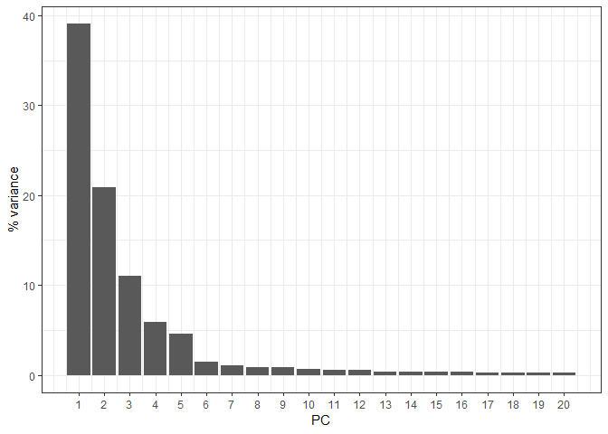

```r
# calculate proportion variance
prop_var <- tibble(Prop_var_raw = pca_raw$sdev^2 *100 / pca_raw$totalvar,
                   PC = 1:20)
p1b <- ggplot(prop_var, aes(x = PC, y = Prop_var_raw)) +
  geom_bar(stat = 'identity') + theme_bw() + labs(y = '% variance') +
  scale_x_continuous(breaks = 1:20);p1b
```